# Port Fairy near-real-time FUNWAVE test

## Interpretation first

This is a 20 m, 30-minute grid and forcing diagnostic—not a validated harbour forecast. Each raw FUNWAVE text field is first rebuilt on the exact rotated Oblique Mercator grid, then reprojected to WGS84 for geographic plotting.

| source_edge | requested_cross_shore_bearing_deg_true | realised_model_x_bearing_deg_true | funwave_theta_peak_deg | inward_source_component | interpretation |
| --- | --- | --- | --- | --- | --- |
| maximum rotated x | 64 | 334.09 | -44.52 | 0.71 | The wave vector has an inward component from the selected source edge. |

## Latest buoy forcing

The irregular `WK_IRR` source is a TMA/JONSWAP-style parameterisation made from the newest usable IMOS Spotter observation. The buoy provides integral Hs, peak period and direction—not a phase-resolved spectrum.

| time_utc | qc | hs_m | tp_s | peak_direction_from_deg_true | peak_direction_to_deg_true | buoy_lon | buoy_lat | requested_cross_shore_bearing_deg_true | model_x_bearing_deg_true | model_y_bearing_deg_true | funwave_theta_peak_deg | inward_source_component |
| --- | --- | --- | --- | --- | --- | --- | --- | --- | --- | --- | --- | --- |
| 2026-09-12 00:15:00 UTC | 1 | 2.11 | 14.62 | 198.51 | 18.51 | 142.29 | -38.38 | 64 | 334.09 | 243.89 | -44.52 | 0.71 |

## Input bathymetry and depth-file checks

The black outline shows the rectangular FUNWAVE grid. All three maps below are displayed in WGS84 only after the native rotated grid has been reconstructed.

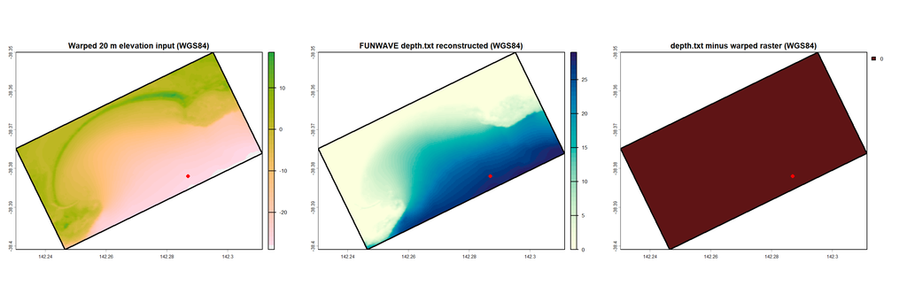

| check | value |
| --- | --- |
| FUNWAVE depth-file dimensions | 161 x 315; expected Mglob x Nglob = 161 x 315 |
| maximum \|depth.txt - warped raster\| | 0.00000000 m |
| wet cells in depth.txt | 72.9% |

## Source orientation diagnostic

The dashed line is the internal wavemaker location. The red arrow is the observed peak-wave **travel** direction after conversion from the buoy’s reported **from** direction into the actual rotated model axes. An arrow with a leftward component leaves the source side and is a forcing-geometry problem, not a bathymetry result.

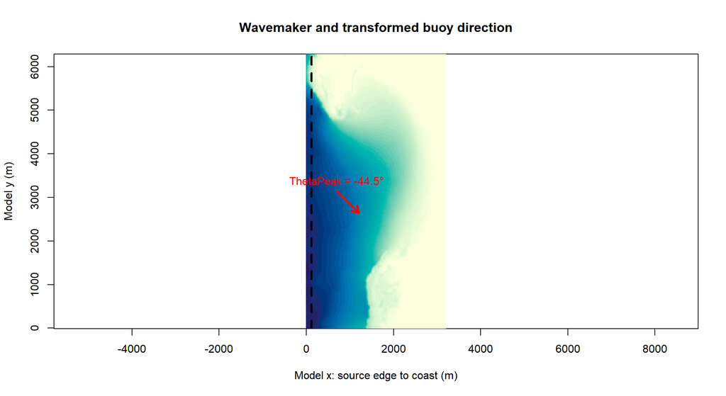

## FUNWAVE depth read-back

`DEPTH_OUT = T` asks FUNWAVE to write the depth it read. The difference panel is the direct end-to-end check; values near zero confirm that the model did not transpose or flip the supplied bathymetry.

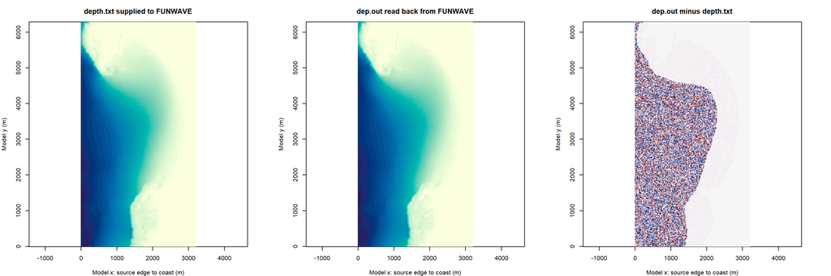